# Quality Control & Sample Size Estimation

Author

Functional Genomics Center Zurich

Published

October 23, 2026

**Overview**

Samples**20**

Groups**5**

Proteins**163**

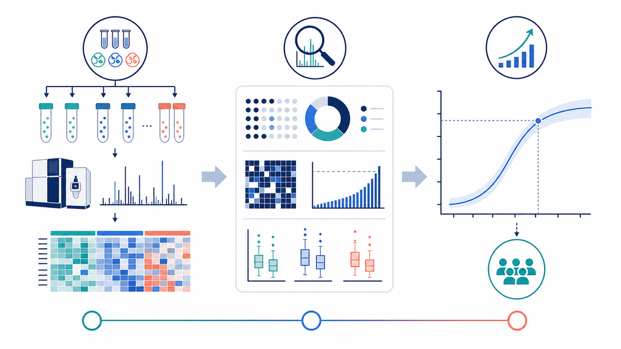

We ran your samples through the same analysis pipeline that will be applied to the main experiment. This document summarizes the protein variability, assesses the reproducibility of the biological samples, and estimates the sample sizes needed for the main experiment.

The **Quality Control** tab describes detection, reproducibility, abundance distributions, and variability. **Sample Size Calculation** then uses the measured variability to size the main experiment for biologically relevant effect sizes.

**NoteAbout this report**

This report is generated automatically and contains no experiment-specific conclusions. Please discuss it with your project bioinformatician or statistician (who is typically not your project coach).

**Quality Control**

Each tab below covers one aspect of data quality, from feature detection through sample-to-sample structure.

**Feature Detection**

Here we summarize the number of proteins measured in the QC experiment. Depending on the type of your sample (e.g., pull-down, supernatant, whole cell lysate) we observe some dozens up to a few thousands of proteins. While the overall number of proteins can vary widely with the type of experiment, it is crucial that the number of proteins is similar between your biological replicates (reproducibility).

Table 1: Number of proteins detected across all samples.

| NR.isotope | NR.protein_Id | NR.peptide_Id |
| --- | --- | --- |
| light | 163 | 1258 |

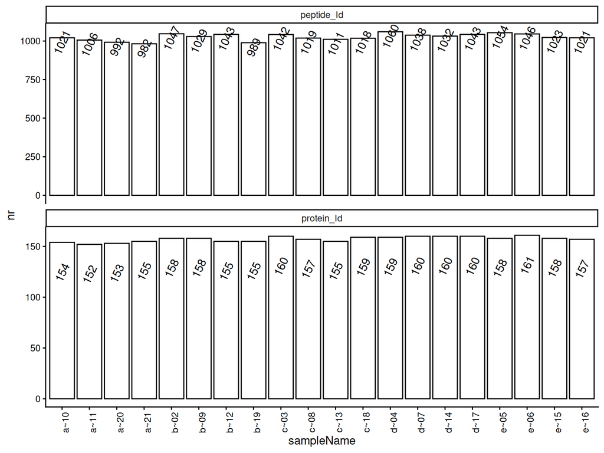

Figure 1: Number of quantified proteins per sample. Each bar is one LC-MS sample; the y-axis is the count of quantified proteins.

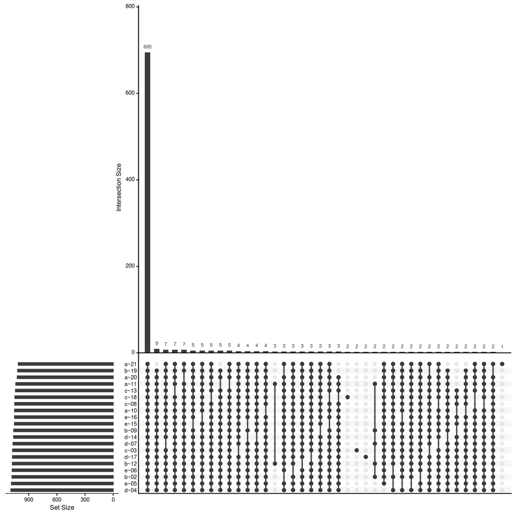

**Missing Values**

Ideally, we identify each protein in all of the samples. However, because of the limit of detection (LOD) low-intensity proteins might not be observed in all samples. Ideally, the LOD should be the only source of missingness in biological replicates. Figure 3 and Figure 4 help us verify the reproducibility of the measurement at the level of missing data: missingness should be confined to low-intensity proteins and should not separate replicates of the same group.

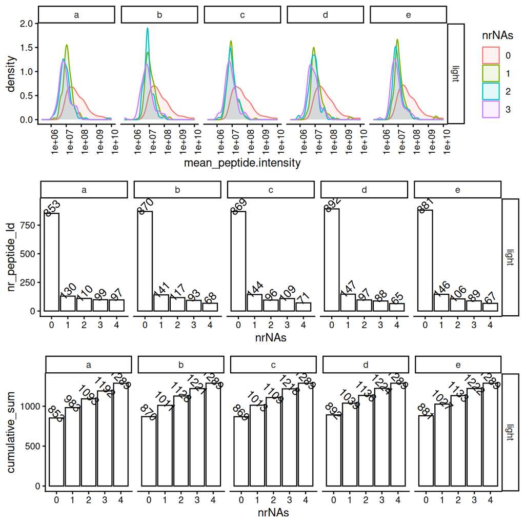

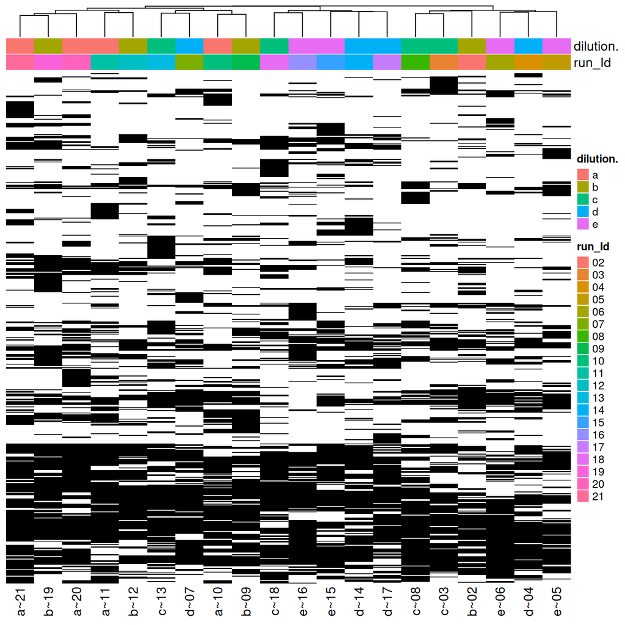

Figure 4: Missing protein quantifications clustered by sample. Rows are proteins, columns are samples; the heatmap marks observed and missing measurements.

**Abundance Distributions**

Normalization removes systematic differences between samples, for example from differing sample amounts or loading. Figure 5 compares the protein intensity distributions before and after variance-stabilizing normalization (vsn); after normalization the sample distributions should be similar.

[interactive chart not shown]

Figure 5: Sample-level intensity distributions before and after transformation. The left panel shows raw protein intensities, the right panel transformed intensities; each curve or violin is one sample.

**Variance**

**Coefficient of variation (raw)**

Before scaling and normalization, the protein intensities should have comparable variability across samples. We assess this with protein -level coefficient of variation (CV) densities (Figure 6); Table 2 summarizes the CV quantiles. Ideally the within-group CV is smaller than the CV across all samples.

[interactive chart not shown]

Figure 6: Distribution of protein-level coefficients of variation (CV, in %) before transformation. The left panel shows CV densities by group; the right panel splits proteins into below- and above-median abundance strata.

Table 2: Coefficient of variation (CV, in %) quantiles at the 50th, 60th, 70th, 80th and 90th percentiles.

| probs | e | a | b | c | d | All |
| --- | --- | --- | --- | --- | --- | --- |
| 0.5 | 19.84 | 17.19 | 18.28 | 18.27 | 18.35 | 22.33 |
| 0.6 | 22.59 | 20.18 | 21.13 | 21.04 | 21.47 | 25.65 |
| 0.7 | 25.94 | 23.50 | 24.87 | 24.89 | 25.27 | 30.16 |
| 0.8 | 32.06 | 28.34 | 30.73 | 31.43 | 31.74 | 35.63 |
| 0.9 | 42.69 | 41.06 | 40.28 | 43.83 | 40.85 | 43.74 |

**Standard deviation (transformed)**

We applied the `vsn::justvsn` normalization, which removes systematic differences between samples and reduces within-group variance. The coefficient of variation is only interpretable on a ratio scale with a meaningful zero; after variance-stabilizing normalization the intensities are on an approximately $\log_2$ scale where $sd/mean$ is no longer meaningful, so we quantify variability directly as the standard deviation (SD) on the transformed scale. Because that scale is roughly $\log_2$, this SD approximates the relative (fold-change) error on the original scale — exactly the input a fold-change-based power calculation requires. Figure 7 shows the distribution of protein SDs, Figure 8 their empirical cumulative distribution function (ECDF), and Table 3 summarizes the SD quantiles.

[interactive chart not shown]

Figure 7: Distribution of protein standard deviations after transformation. The left panel shows SD densities by group; the right panel splits proteins into below- and above-median abundance strata.

[interactive chart not shown]

Figure 8: Empirical cumulative distribution function (ECDF) of protein standard deviations after transformation. The left panel shows SD ECDFs by group; the right panel splits proteins into below- and above-median abundance strata.

Table 3: Standard-deviation quantiles (transformed / vsn scale) at the 50th, 60th, 70th, 80th and 90th percentiles.

| probs | e | a | b | c | d | All |
| --- | --- | --- | --- | --- | --- | --- |
| 0.5 | 0.197 | 0.195 | 0.194 | 0.191 | 0.198 | 0.270 |
| 0.6 | 0.242 | 0.237 | 0.238 | 0.236 | 0.240 | 0.331 |
| 0.7 | 0.301 | 0.293 | 0.298 | 0.285 | 0.296 | 0.407 |
| 0.8 | 0.380 | 0.372 | 0.386 | 0.364 | 0.372 | 0.526 |
| 0.9 | 0.563 | 0.554 | 0.563 | 0.581 | 0.544 | 0.713 |

**Sample Structure**

We also inspect how similar the samples are to each other. Figure 9 shows pairwise sample correlations after transformation, Figure 10 gives an overview of all transformed protein intensities, and Figure 11 compares sample pairs in detail. Replicates of the same group should correlate highly, cluster together, and show tight agreement in the pairwise scatter plots.

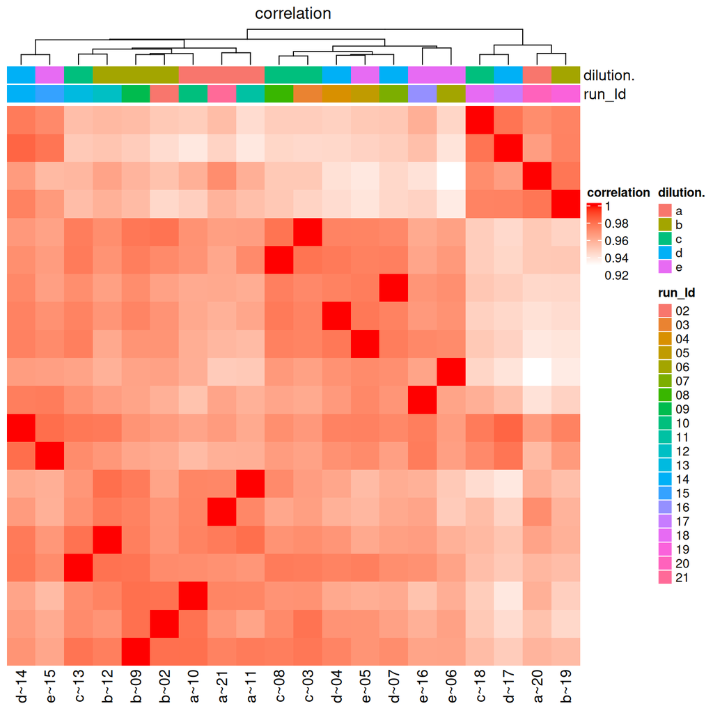

Figure 9: Sample correlation heatmap after transformation. Rows and columns are samples; colours encode pairwise correlations of transformed protein intensities.

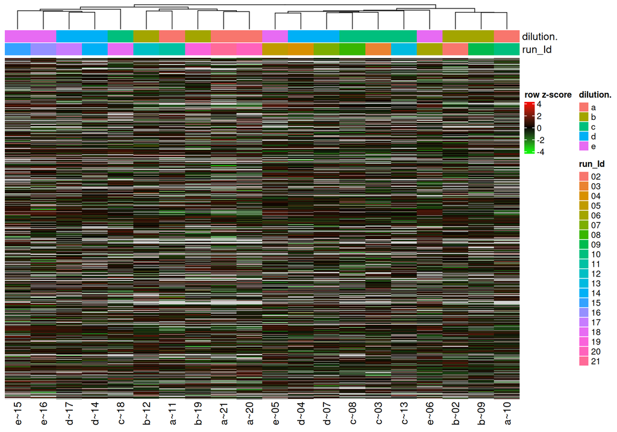

Figure 10: Heatmap of transformed protein intensities across samples. Rows are proteins, columns are samples; colours encode transformed intensity.

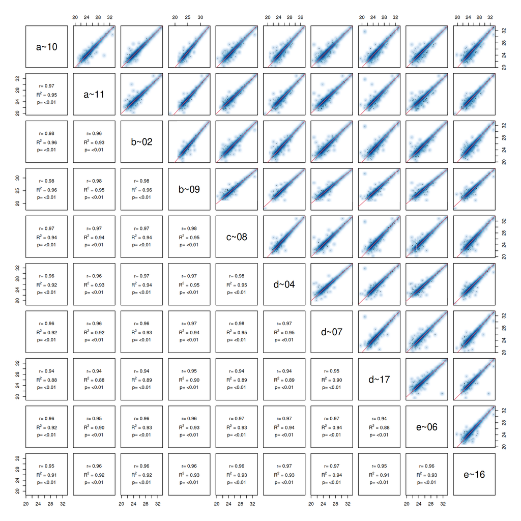

Figure 11: Pairwise scatter plots of transformed sample intensities. Each panel compares two samples; smoothed trends show agreement between samples.

Reproducible QC data show comparable intensity distributions across samples, high sample-to-sample correlations, replicates that cluster together in the overview heatmap, and missingness confined to low-intensity proteins near the limit of detection. Treat clear deviations from these expectations as points to discuss before proceeding, rather than as automated verdicts.

**Sample Size Calculation**

An important factor in estimating sample size is the smallest effect size you want to detect between two conditions, such as a reference and a treatment. Smaller biologically relevant effects require more samples. Typical $log_2$ fold-change thresholds are $0.59, 1, 2$, corresponding to fold changes of $1.5, 2, 4$.

**NoteKey concepts: power, significance, and effect size**

The *power* of a test is $1-\beta$, where $\beta$ is the probability of a Type 2 error (failing to reject the null hypothesis when the alternative hypothesis is true). In other words, if you have a $20\%$ chance of failing to detect a real difference, then the power of your test is $80\%$.

The *confidence level* is equal to $1 - \alpha$, where $\alpha$ is the probability of making a Type 1 error. That is, alpha represents the chance of falsely rejecting $H_0$ and picking up a false-positive effect. Alpha is usually set at a $5\%$ significance level, for a $95\%$ confidence level.

Fold change: suppose you compare a treatment group to a placebo group and measure some continuous response which, you hypothesize, is affected by the treatment. Consider the mean response in the treatment group, $\mu_1$, and in the placebo group, $\mu_2$. Define $\Delta = \mu_1 - \mu_2$ as the mean difference. The smaller the difference you want to detect, the larger the required sample size.

The sub-tabs below give, for each tested $log_2$ fold-change ($0.59, 1, 2$), the number of samples needed per group at a significance level of $5\%$ and power of $80\%$, using the SD quantiles for $50\%$ and $75\%$ of the measured proteins — shown as a bar chart and a table.

**log2 FC 0.59**

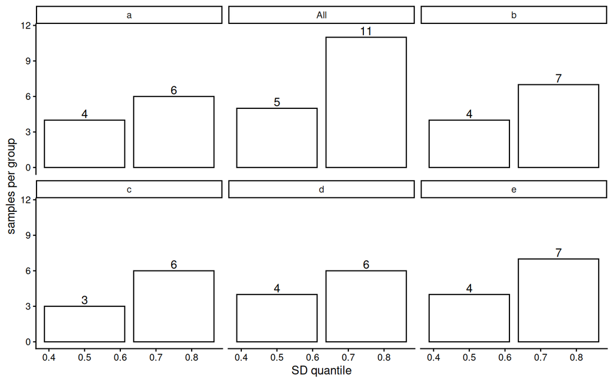

Figure 12: Estimated samples per group to detect a log2 fold-change of 0.59 (fold change 1.5) at significance level 0.05 and power 0.8. Each panel is one experimental group; the two bars are the 50% and 75% SD quantiles of the measured proteins.

Table 4: Samples per group for a log2 fold-change of 0.59 (fold change 1.5), by group and SD quantile.

| dilution. | probs | sdtrimmed | N |
| --- | --- | --- | --- |
| e | 0.50 | 0.197 | 4 |
| e | 0.75 | 0.330 | 7 |
| a | 0.50 | 0.195 | 4 |
| a | 0.75 | 0.328 | 6 |
| b | 0.50 | 0.194 | 4 |
| b | 0.75 | 0.333 | 7 |
| c | 0.50 | 0.191 | 3 |
| c | 0.75 | 0.318 | 6 |
| d | 0.50 | 0.198 | 4 |
| d | 0.75 | 0.327 | 6 |
| All | 0.50 | 0.270 | 5 |
| All | 0.75 | 0.462 | 11 |

**log2 FC 1**

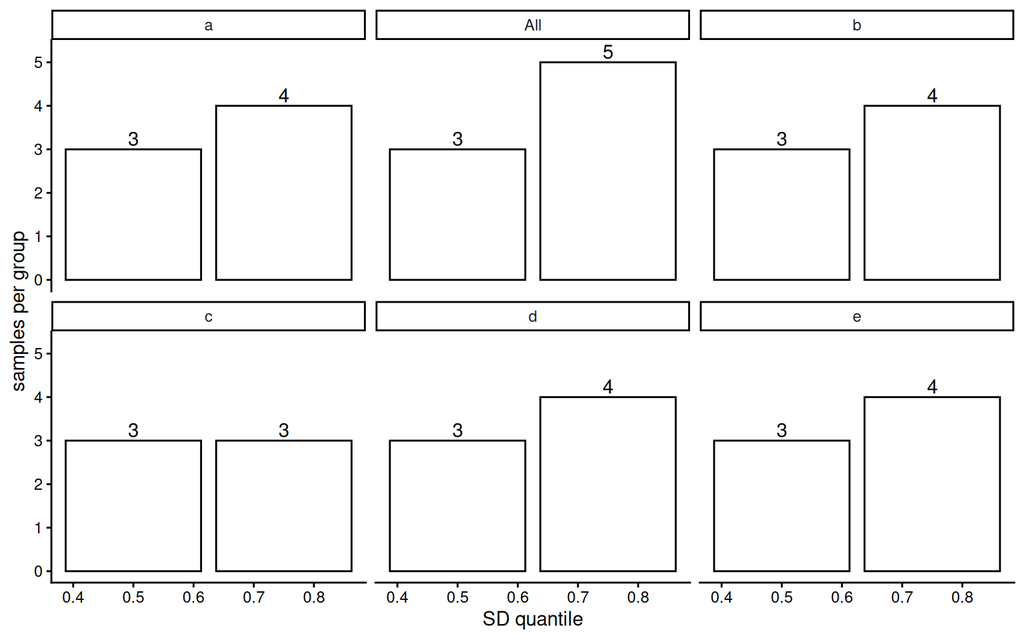

Figure 13: Estimated samples per group to detect a log2 fold-change of 1 (fold change 2) at significance level 0.05 and power 0.8. Each panel is one experimental group; the two bars are the 50% and 75% SD quantiles of the measured proteins.

Table 5: Samples per group for a log2 fold-change of 1 (fold change 2), by group and SD quantile.

| dilution. | probs | sdtrimmed | N |
| --- | --- | --- | --- |
| e | 0.50 | 0.197 | 3 |
| e | 0.75 | 0.330 | 4 |
| a | 0.50 | 0.195 | 3 |
| a | 0.75 | 0.328 | 4 |
| b | 0.50 | 0.194 | 3 |
| b | 0.75 | 0.333 | 4 |
| c | 0.50 | 0.191 | 3 |
| c | 0.75 | 0.318 | 3 |
| d | 0.50 | 0.198 | 3 |
| d | 0.75 | 0.327 | 4 |
| All | 0.50 | 0.270 | 3 |
| All | 0.75 | 0.462 | 5 |

**log2 FC 2**

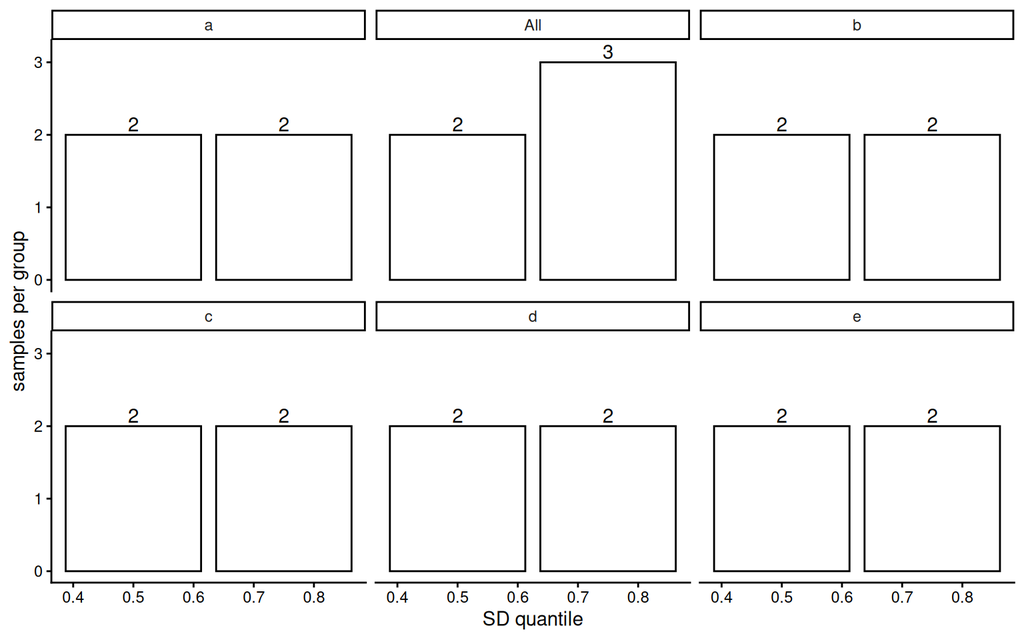

Figure 14: Estimated samples per group to detect a log2 fold-change of 2 (fold change 4) at significance level 0.05 and power 0.8. Each panel is one experimental group; the two bars are the 50% and 75% SD quantiles of the measured proteins.

Table 6: Samples per group for a log2 fold-change of 2 (fold change 4), by group and SD quantile.

| dilution. | probs | sdtrimmed | N |
| --- | --- | --- | --- |
| e | 0.50 | 0.197 | 2 |
| e | 0.75 | 0.330 | 2 |
| a | 0.50 | 0.195 | 2 |
| a | 0.75 | 0.328 | 2 |
| b | 0.50 | 0.194 | 2 |
| b | 0.75 | 0.333 | 2 |
| c | 0.50 | 0.191 | 2 |
| c | 0.75 | 0.318 | 2 |
| d | 0.50 | 0.198 | 2 |
| d | 0.75 | 0.327 | 2 |
| All | 0.50 | 0.270 | 2 |
| All | 0.75 | 0.462 | 3 |

**Sample Mapping**

Table 7: Sample annotation table mapping raw file names to sample names and their experimental group/condition assignments used throughout this report.

| raw.file | sampleName | dilution. | run_Id |
| --- | --- | --- | --- |
| b03_10_150304_human_ecoli_a_3ul_3um_column_95_hcd_ot_2hrs_30b_9b | a~10 | a | 10 |
| b03_11_150304_human_ecoli_a_3ul_3um_column_95_hcd_ot_2hrs_30b_9b | a~11 | a | 11 |
| b03_20_150304_human_ecoli_a_3ul_3um_column_95_hcd_ot_2hrs_30b_9b | a~20 | a | 20 |
| b03_21_150304_human_ecoli_a_3ul_3um_column_95_hcd_ot_2hrs_30b_9b | a~21 | a | 21 |
| b03_02_150304_human_ecoli_b_3ul_3um_column_95_hcd_ot_2hrs_30b_9b | b~02 | b | 02 |
| b03_09_150304_human_ecoli_b_3ul_3um_column_95_hcd_ot_2hrs_30b_9b | b~09 | b | 09 |
| b03_12_150304_human_ecoli_b_3ul_3um_column_95_hcd_ot_2hrs_30b_9b | b~12 | b | 12 |
| b03_19_150304_human_ecoli_b_3ul_3um_column_95_hcd_ot_2hrs_30b_9b | b~19 | b | 19 |
| b03_03_150304_human_ecoli_c_3ul_3um_column_95_hcd_ot_2hrs_30b_9b | c~03 | c | 03 |
| b03_08_150304_human_ecoli_c_3ul_3um_column_95_hcd_ot_2hrs_30b_9b | c~08 | c | 08 |
| b03_13_150304_human_ecoli_c_3ul_3um_column_95_hcd_ot_2hrs_30b_9b | c~13 | c | 13 |
| b03_18_150304_human_ecoli_c_3ul_3um_column_95_hcd_ot_2hrs_30b_9b | c~18 | c | 18 |
| b03_04_150304_human_ecoli_d_3ul_3um_column_95_hcd_ot_2hrs_30b_9b | d~04 | d | 04 |
| b03_07_150304_human_ecoli_d_3ul_3um_column_95_hcd_ot_2hrs_30b_9b | d~07 | d | 07 |
| b03_14_150304_human_ecoli_d_3ul_3um_column_95_hcd_ot_2hrs_30b_9b | d~14 | d | 14 |
| b03_17_150304_human_ecoli_d_3ul_3um_column_95_hcd_ot_2hrs_30b_9b | d~17 | d | 17 |
| b03_05_150304_human_ecoli_e_3ul_3um_column_95_hcd_ot_2hrs_30b_9b | e~05 | e | 05 |
| b03_06_150304_human_ecoli_e_3ul_3um_column_95_hcd_ot_2hrs_30b_9b | e~06 | e | 06 |
| b03_15_150304_human_ecoli_e_3ul_3um_column_95_hcd_ot_2hrs_30b_9b | e~15 | e | 15 |
| b03_16_150304_human_ecoli_e_3ul_3um_column_95_hcd_ot_2hrs_30b_9b | e~16 | e | 16 |

The per-sample counts plotted in Figure 1 are tabulated below.

Table 8: Number of quantified proteins per sample.

| isotope | sampleName | protein_Id | peptide_Id |
| --- | --- | --- | --- |
| light | a~10 | 154 | 1021 |
| light | a~11 | 152 | 1006 |
| light | a~20 | 153 | 992 |
| light | a~21 | 155 | 982 |
| light | b~02 | 158 | 1047 |
| light | b~09 | 158 | 1029 |
| light | b~12 | 155 | 1043 |
| light | b~19 | 155 | 989 |
| light | c~03 | 160 | 1042 |
| light | c~08 | 157 | 1019 |
| light | c~13 | 155 | 1011 |
| light | c~18 | 159 | 1018 |
| light | d~04 | 159 | 1060 |
| light | d~07 | 160 | 1038 |
| light | d~14 | 160 | 1032 |
| light | d~17 | 160 | 1043 |
| light | e~05 | 158 | 1054 |
| light | e~06 | 161 | 1046 |
| light | e~15 | 158 | 1023 |
| light | e~16 | 157 | 1021 |

**Session Info**

**Report provenance**

Table 9: Compact report provenance, including the source input-data reference.

| Field | Value |
| --- | --- |
| Workunit ID | n/a |
| Order ID | n/a |
| Project ID | n/a |
| Project name | n/a |
| Creator | runner |
| Created at | 2026-10-23 05:09:55 UTC |
| Input data | n/a |
| Quantification software | n/a |
| Model | n/a |
| prolfquapp version | 2.11.0 |

**R session info**

[session information not shown]

*This report was generated from the Quarto template `QCandSSE_tabset.qmd` included in the `prolfquapp` R package (version 2.11.0).*

## Download

- Qmd source
- HTML page

Select all plots

Plots download at the resolution embedded in the report (its fig-dpi). Interactive (plotly) charts aren't listed — export those from their own toolbar.